# european_migration_report

**Final Project: Understanding EU Immigration Dynamics: EDA and Predictive Modeling**

**1 Introduction: Supervised Learning Problem Description and Project Overview**

The dataset analyzed contains information on immigration and emigration trends across selected European countries. It encompasses various demographic factors such as age, gender, and geographic origin of migrants, allowing for a detailed exploration of migration patterns over time.

**Supervised Learning Problem Description:**

Given the demographic and historical immigration data, the objective is to develop predictive models that can accurately forecast immigration in reporting reporting European countries based on demographic features such as age, gender, and country of origin.

Using supervised learning algorithms, models can be trained on existing labeled data where the target variable represents the total immigration to a particular European country within a specified time period. The models learn and identify patterns and relationships within the data to make predictions.

**Overview of EDA Procedure:**

1. Data Preprocessing: This initial step involves importing the datasets and formatting them into suitable dataframe format for analysis.
2. Data Cleaning: This step emphasizes the handling missing values, defining appropriate data types for each column, and ensuring the overall integrity of the dataset.
3. Exploratory Data Analysis: EDA encompasses the examination of variable distributions. Insights into distribution of demographic factors and trends over time are explored and visualizations such as histograms, scatter plots, and time series plots will be utilized.
4. Feature Engineering: New features are added and existing features are transformed to enhance the performance of models.
5. Statistical Analysis: Statistical tests are performed to uncover relationships and dependencies between different variables.
6. Dimensionality Reduction: Techniques such as Principal Component Analysis (PCA) are utilized to reduce the dimensionality of the dataset while preserving important information.

**Overview of Analysis:**

Various machine learning models used to predict immigration patterns based on the demographic and historical immigration data are explored. Models are selected taking into consideration factors such as interpretability, performance, and scalability. Then they are trained using preprocessed data, their performance is evaluated using metrics such as RMSE and MAE, and their hyperparameters are adjusted to optimize performance. Additionally, cross-validation is performed to assess model generalization performance and detect overfitting.

**Overview of Results:**

This includes performance metrics such as MSE, MAE, and other relevant evaluation metrics for both the training and test datasets. The results include visualizations of the performance of the models using appropriate plots and charts to provide insights into their effectiveness in predicting immigration patterns.

**Overview of Conclusion:**

Summary of findings including limitations, challenges, and potential future research.

**2.1 EDA Procedure: Data Preprocessing**

The following data preprocessing reads in datasets all found from Eurostat, the official statistical office of the European Union: https://ec.europa.eu/eurostat/web/migration-asylum/international-migration-citizenship/database

The initial datasets selected are:

1. Immigration by age group, sex and citizenship
2. Immigration by age group, sex and country of birth
3. Immigration by age group, sex and country of previous residence
4. Emigration by age group, sex and country of next usual residence

They contain data on immigrants/emigrants by age group, sex, destination country, and either the previous residence, country of birth, or citizenship of immigrants/emigrants.

The following additional datasets were loaded in during feature engineering and can be found from the Eurostat database as well via: https://ec.europa.eu/eurostat/databrowser/explore/all/t_popul?lang=en&subtheme=t_demo&display=list&sort=category

The additional datasets selected are:

1. Population (National Level)
2. Total Fertility Rate

```python
# Import Libraries
import pandas as pd
import matplotlib.pyplot as plt
import seaborn as sns
import numpy as np
from functools import reduce
from sklearn.cluster import KMeans
from sklearn.decomposition import PCA
import statsmodels.api as sm
from statsmodels.formula.api import ols
from scipy import stats
from scipy.stats import chi2_contingency
from sklearn.compose import ColumnTransformer
from sklearn.preprocessing import StandardScaler, OneHotEncoder
from sklearn.pipeline import Pipeline
from sklearn.model_selection import train_test_split
from sklearn.ensemble import RandomForestRegressor
from sklearn.linear_model import LinearRegression
from sklearn.metrics import mean_squared_error, mean_absolute_error

# Read in Datasets
file_path_residence = 'migr_imm5prv_tabular.tsv'
file_path_citizenship = 'migr_imm1ctz_tabular.tsv'
file_path_birth = 'migr_imm3ctb_tabular.tsv'
file_path_emigration = 'migr_emi3nxt_tabular.tsv'
file_path_population = 'population.tsv'
file_path_fertility = 'fertility.tsv'

# Load datasets into dataframes
df_residence = pd.read_csv(file_path_residence, delimiter='\t')
df_citizenship = pd.read_csv(file_path_citizenship, delimiter='\t')
df_birth = pd.read_csv(file_path_birth, delimiter='\t')
df_emigration = pd.read_csv(file_path_emigration, delimiter='\t')
df_population = pd.read_csv(file_path_population, delimiter='\t')
df_fertility = pd.read_csv(file_path_fertility, delimiter='\t')

# Define categorical columns
categorical_columns = ['geo_world', 'sex', 'age', 'geo_eu', 'agedef']

# Define special values which are NaN values according to data keys
special_values = [':']

# Create function to replace cells containing special values with NaN and addressing estimate and provisional special characters according to data keys
def replace_special_values(cell):
        if any(val in str(cell) for val in special_values):
            return float('nan')
        elif any(char in str(cell) for char in ['e', 'p', 'b', 's', '(', ')']):
            # Keep numeric values if 'e', 'p', 'b', or parentheses are present in the cell
            cell = ''.join(char for char in str(cell) if char.isnumeric() or char == '.' or char == '-')
            return cell.strip()
        return cell

# Define columns with string split
for df in [df_residence, df_citizenship, df_birth, df_emigration, df_population, df_fertility]:

    # Adjust the order of string split and column renaming for df_residence
    if df is df_residence:
        df[['freq', 'geo_world', 'agedef', 'age', 'unit', 'sex', 'geo_eu']] = df['freq,partner,agedef,age,unit,sex,geo\TIME_PERIOD'].str.split(',', expand=True)
        # Drop the original pre-split column
        df.drop(columns=['freq,partner,agedef,age,unit,sex,geo\TIME_PERIOD'], inplace=True)
    elif df is df_birth:
        df[['freq', 'age', 'agedef', 'geo_world', 'unit', 'sex', 'geo_eu']] = df['freq,age,agedef,c_birth,unit,sex,geo\TIME_PERIOD'].str.split(',', expand=True)
        # Drop the original pre-split column
        df.drop(columns=['freq,age,agedef,c_birth,unit,sex,geo\TIME_PERIOD'], inplace=True)
    elif df is df_citizenship:
        df[['freq', 'geo_world','agedef', 'age', 'unit', 'sex', 'geo_eu']] = df['freq,citizen,agedef,age,unit,sex,geo\TIME_PERIOD'].str.split(',', expand=True)
        # Drop the original pre-split column
        df.drop(columns=['freq,citizen,agedef,age,unit,sex,geo\TIME_PERIOD'], inplace=True)
    elif df is df_emigration:
        df[['freq', 'geo_world','agedef', 'age', 'unit', 'sex', 'geo_eu']] = df['freq,partner,agedef,age,unit,sex,geo\TIME_PERIOD'].str.split(',', expand=True)
        # Drop the original pre-split column
        df.drop(columns=['freq,partner,agedef,age,unit,sex,geo\TIME_PERIOD'], inplace=True)
    else:
        df[['freq', 'unit', 'geo_eu']] = df['freq,indic_de,geo\TIME_PERIOD'].str.split(',', expand=True)
        # Drop the original pre-split column
        df.drop(columns=['freq,indic_de,geo\TIME_PERIOD'], inplace=True)

    df.drop(['freq', 'unit'], axis=1, inplace=True)

    # Specify columns to apply replace_special_values to
    numeric_columns = [col for col in df.columns if col not in categorical_columns]

    # Apply replace_special_values
    for column in numeric_columns:
        df[column] = df[column].apply(replace_special_values)

# Strip strings
for df in [df_residence, df_citizenship, df_birth, df_emigration, df_population, df_fertility]:
    for column in df.columns:
        if df[column].dtype == 'category':
            df[column] = df[column].str.strip()
    for column in df.columns:
        if df[column].dtype == 'object':
            df[column] = df[column].str.strip()

# Define a dictionary to help melt the dataframes by Year
melt_mappings = {
    'df_residence': 'world_to_eu_residence',
    'df_citizenship': 'world_to_eu_citizenship',
    'df_birth': 'world_to_eu_birth',
    'df_emigration': 'eu_to_world_residence',
    'df_population': 'geo_eu_population',
    'df_fertility': 'geo_eu_fertility'
}

# Melt the dataframes
for df_var, value_name in melt_mappings.items():
    df = globals()[df_var]
    id_vars = [col for col in categorical_columns if col in df.columns]
    melted_df = pd.melt(df, id_vars=id_vars, var_name='Year', value_name=value_name)
    globals()[df_var] = melted_df

#Define the list of data frames
data_frames = [df_residence, df_citizenship, df_birth, df_emigration, df_population, df_fertility]

# Strip strings
for df in data_frames:
    df.columns = df.columns.str.strip()

# Define categorical columns fore each dataframe
categorical_columns = {
    'df_residence': ['geo_eu', 'geo_world', 'age', 'sex', 'agedef'],
    'df_citizenship': ['geo_eu', 'geo_world', 'age', 'sex', 'agedef'],
    'df_birth': ['geo_eu', 'geo_world', 'age', 'sex', 'agedef'],
    'df_emigration': ['geo_eu', 'geo_world', 'age', 'sex', 'agedef'],
    'df_population': ['geo_eu'],
    'df_fertility': ['geo_eu']
}

# Define numeric columns fore each dataframe
numeric_columns = {
    'df_residence': ['Year', 'world_to_eu_residence'],
    'df_citizenship': ['Year', 'world_to_eu_citizenship'],
    'df_birth': ['Year', 'world_to_eu_birth'],
    'df_emigration': ['Year', 'eu_to_world_residence'],
    'df_population': ['Year', 'geo_eu_population'],
    'df_fertility': ['Year', 'geo_eu_fertility']
}

# Convert categorical columns to 'category' data type
for df_name, df in zip(['df_residence', 'df_citizenship', 'df_birth', 'df_emigration', 'df_population', 'df_fertility'], data_frames):
    for col in categorical_columns[df_name]:
        if col in df.columns:
            df[col] = df[col].astype('category')

# Convert numeric columns to appropriate data types
for df_name, df in zip(['df_residence', 'df_citizenship', 'df_birth', 'df_emigration', 'df_population', 'df_fertility'], data_frames):
    for col in numeric_columns[df_name]:
        if col == 'Year':
            df[col] = pd.to_numeric(df[col])
        else:
            # Convert to integer if the column represents a whole number
            df[col] = pd.to_numeric(df[col], errors='coerce')
```

**2.2 EDA Procedure: Data Cleaning**

As population and fertility of the European countries were added later as part of feature engineering, data cleaning largely focuses on the immigration/emigration data.

After removing redundant data and defining a common dataset, it is apparent in the Eurostat data that some countries report immigration data by measuring the age of the immigrant at the time of immigration, while others report data by measuring the age of the immigrant that will be reached in the calendar year of immigration, and very few countries provide both measurements.

In order to minimize information loss, and given that if all data was complete then immigrants would be measured once by each method, the reporting European country age type with more information is used.

After selecting relevant data, mapping is applied to categorical variable types.

As the volume of missing fertility data is minimal, the information is entered from: https://wdi.worldbank.org/table/2.14.

While single the missing population entry is entered from the nearest available date from the UK Office of National Statistics found: https://www.ons.gov.uk/peoplepopulationandcommunity/populationandmigration/populationestimates/bulletins/populationestimatesforenglandandwales/mid2022.

The primary dataframe for analysis is df_immigration, with df_population and df_fertility data available as part of feature engineering.

```python
data_frames = [df_residence, df_citizenship, df_birth, df_emigration, df_population, df_fertility]

def clean_data_frames(data_frames):
    # Extract unique years for each data frame
    unique_years_list = [set(df['Year'].unique()) for df in data_frames]

    # Find the intersection of unique years across all data frames
    common_years = set.intersection(*unique_years_list)

    # Intersection of unique 'geo_eu' values across all data frames
    common_geo_eu_values = ['CY', 'PL', 'DK', 'HU', 'EL', 'SK', 'UA', 'FR', 'LU', 'IT', 'LT', 'ME', 'FI', 'MK', 'CH', 'NL', 'CZ', 'PT', 'RO', 'SI', 'NO', 'ES', 'LI', 'AT', 'BE', 'EE', 'UK', 'IE', 'HR', 'IS', 'LV', 'BG', 'DE', 'MT', 'SE']

    # Values to exclude from dropping in 'geo_world'
    exclude_geo_world_values = ['RNC', 'UNK']

    cleaned_data_frames = []

    for df in data_frames:

        # Keep only rows with years that are common across all data frames
        df = df[df['Year'].isin(common_years)]

        # Keep only rows with 'geo_eu' values common across all data frames
        df = df[df['geo_eu'].isin(common_geo_eu_values)]

        # Delete 'geo_world' values more than two characters, excluding specified values if the column exists
        if 'geo_world' in df.columns:
            df = df[df['geo_world'].apply(lambda x: len(str(x)) <= 2 or x in exclude_geo_world_values)]

        # Remove rows where 'age' is 'TOTAL', 'Y15-64', 'Y_GE65', 'Y_GE85' if the 'age' column exists
        if 'age' in df.columns:
            df = df[~df['age'].isin(['TOTAL','Y_LT15','Y15-64', 'Y_GE65', 'Y_GE85', 'UNK'])]

        # Remove rows where 'sex' is 'TOTAL' if the 'sex' column exists
        if 'sex' in df.columns:
            df = df[df['sex'] != 'T']

        # Reset the index
        df = df.reset_index(drop=True)

        cleaned_data_frames.append(df)

    return cleaned_data_frames


# Apply the cleaning function
cleaned_data_frames = clean_data_frames(data_frames)

# Assign the cleaned data frames back to individual variables
df_residence, df_citizenship, df_birth, df_emigration, df_population, df_fertility = cleaned_data_frames
```

```python
def separate_agedef_data_frames(data_frames):
    agedef_reach_data_frames = []
    agedef_complet_data_frames = []

    for df in data_frames:
        # Separate rows where 'agedef' is equal to 'REACH' and 'COMPLET'
        if 'agedef' in df.columns:
            df_reach = df[df['agedef'] == 'REACH'].drop(columns=['agedef']).reset_index(drop=True)
            df_complet = df[df['agedef'] == 'COMPLET'].drop(columns=['agedef']).reset_index(drop=True)
        else:
            df_reach = df.reset_index(drop=True)
            df_complet = df.reset_index(drop=True)

        agedef_reach_data_frames.append(df_reach)
        agedef_complet_data_frames.append(df_complet)

    return agedef_reach_data_frames, agedef_complet_data_frames

# Separate data frames based on 'agedef' values and drop the 'agedef' column
df_residence_reach, df_residence_complet = separate_agedef_data_frames([df_residence])
df_citizenship_reach, df_citizenship_complet = separate_agedef_data_frames([df_citizenship])
df_birth_reach, df_birth_complet = separate_agedef_data_frames([df_birth])
df_emigration_reach, df_emigration_complet = separate_agedef_data_frames([df_emigration])
```

```python
def filter_and_clean(df_reach, df_complet, column_name):
    df_reach_filtered = pd.concat([df.loc[(df[column_name].notna()) & (df[column_name] > 0)] for df in df_reach])
    df_complet_filtered = pd.concat([df.loc[(df[column_name].notna()) & (df[column_name] > 0)] for df in df_complet])

    # Compare totals
    reach_totals = df_reach_filtered.groupby('geo_eu')[column_name].sum()
    complet_totals = df_complet_filtered.groupby('geo_eu')[column_name].sum()

    # Create cleaned data frame
    df_cleaned = pd.DataFrame(columns=['geo_world', 'sex', 'age', 'geo_eu', 'Year', column_name])

    # Populate column based on larger total
    for geo_eu in reach_totals.index:
        if reach_totals[geo_eu] > complet_totals[geo_eu]:
            df_temp = df_reach_filtered[df_reach_filtered['geo_eu'] == geo_eu]
        elif reach_totals[geo_eu] < complet_totals[geo_eu]:
            df_temp = df_complet_filtered[df_complet_filtered['geo_eu'] == geo_eu]
        else:
            continue
        df_cleaned = pd.concat([df_cleaned, df_temp])

    df_cleaned.reset_index(drop=True, inplace=True)

    return df_cleaned

# Apply the function for each data set
df_residence_cleaned = filter_and_clean(df_residence_reach, df_residence_complet, 'world_to_eu_residence')
df_citizenship_cleaned = filter_and_clean(df_citizenship_reach, df_citizenship_complet, 'world_to_eu_citizenship')
df_birth_cleaned = filter_and_clean(df_birth_reach, df_birth_complet, 'world_to_eu_birth')
df_emigration_cleaned = filter_and_clean(df_emigration_reach, df_emigration_complet, 'eu_to_world_residence')
```

```python
# Updated list of dataframes
data_frames = [df_residence_cleaned, df_citizenship_cleaned, df_birth_cleaned, df_emigration_cleaned, df_population, df_fertility]

# Define categorical columns and numeric columns for each dataframe
categorical_columns = {
    'df_residence_cleaned': ['geo_eu', 'geo_world', 'age', 'sex'],
    'df_citizenship_cleaned': ['geo_eu', 'geo_world', 'age', 'sex'],
    'df_birth_cleaned': ['geo_eu', 'geo_world', 'age', 'sex'],
    'df_emigration_cleaned': ['geo_eu', 'geo_world', 'age', 'sex'],
    'df_population': ['geo_eu'],
    'df_fertility': ['geo_eu']
}

numeric_columns = {
    'df_residence_cleaned': ['Year', 'world_to_eu_residence'],
    'df_citizenship_cleaned': ['Year', 'world_to_eu_citizenship'],
    'df_birth_cleaned': ['Year', 'world_to_eu_birth'],
    'df_emigration_cleaned': ['Year', 'eu_to_world_residence'],
    'df_population': ['Year', 'geo_eu_population'],
    'df_fertility': ['Year', 'geo_eu_fertility']
}

# Convert categorical columns to 'category' data type
for df_name, df in zip(['df_residence_cleaned', 'df_citizenship_cleaned', 'df_birth_cleaned', 'df_emigration_cleaned', 'df_population', 'df_fertility'], data_frames):
    for col in categorical_columns[df_name]:
        if col in df.columns:
            df[col] = df[col].astype('category')

# Convert numeric columns to appropriate data types
for df_name, df in zip(['df_residence_cleaned', 'df_citizenship_cleaned', 'df_birth_cleaned', 'df_emigration_cleaned', 'df_population', 'df_fertility'], data_frames):
    for col in numeric_columns[df_name]:
        if col == 'Year':
            df[col] = pd.to_numeric(df[col])
        else:
            # Convert to integer if the column represents a whole number
            df[col] = pd.to_numeric(df[col], errors='coerce')
```

```python
# Updated categorical columns
categorical_columns = ['geo_world', 'sex', 'age', 'geo_eu']

# Updated dataframes list
data_frames = [df_residence_cleaned, df_citizenship_cleaned, df_birth_cleaned, df_emigration_cleaned, df_population, df_fertility]

# geo_eu mapping
geo_eu_mapping = {
    'CY': 'Cyprus',
    'FR': 'France',
    'CZ': 'Czechia',
    'IT': 'Italy',
    'PL': 'Poland',
    'SI': 'Slovenia',
    'DK': 'Denmark',
    'ES': 'Spain',
    'SK': 'Slovakia',
    'LV': 'Latvia',
    'DE': 'Germany',
    'EL': 'Greece',
    'FI': 'Finland',
    'HR': 'Croatia',
    'IE': 'Ireland',
    'SE': 'Sweden',
    'PT': 'Portugal',
    'LI': 'Liechtenstein',
    'NL': 'Netherlands',
    'RO': 'Romania',
    'HU': 'Hungary',
    'IS': 'Iceland',
    'UA': 'Ukraine',
    'CH': 'Switzerland',
    'EE': 'Estonia',
    'ME': 'Montenegro',
    'BE': 'Belgium',
    'LU': 'Luxembourg',
    'LT': 'Lithuania',
    'MK': 'North Macedonia',
    'NO': 'Norway',
    'BG': 'Bulgaria',
    'MT': 'Malta',
    'AT': 'Austria',
    'UK': 'United Kingdom'
}

# geo_world mapping
geo_world_mapping = {
    'AD': 'Andorra',
    'AE': 'United Arab Emirates',
    'AF': 'Afghanistan',
    'AG': 'Antigua and Barbuda',
    'AI': 'Anguilla',
    'AL': 'Albania',
    'AM': 'Armenia',
    'AN': 'Netherlands Antilles',
    'AO': 'Angola',
    'AQ': 'Antarctica',
    'AR': 'Argentina',
    'AS': 'American Samoa',
    'AT': 'Austria',
    'AU': 'Australia',
    'AW': 'Aruba',
    'AZ': 'Azerbaijan',
    'BA': 'Bosnia and Herzegovina',
    'BB': 'Barbados',
    'BD': 'Bangladesh',
    'BE': 'Belgium',
    'BF': 'Burkina Faso',
    'BG': 'Bulgaria',
    'BH': 'Bahrain',
    'BI': 'Burundi',
    'BJ': 'Benin',
    'BL': 'Saint Barthélemy',
    'BM': 'Bermuda',
    'BN': 'Brunei',
    'BO': 'Bolivia',
    'BQ': 'Bonaire, Sint Eustatius, and Saba',
    'BR': 'Brazil',
    'BS': 'Bahamas',
    'BT': 'Bhutan',
    'BW': 'Botswana',
    'BY': 'Belarus',
    'BZ': 'Belize',
    'CA': 'Canada',
    'CC': 'Cocos (Keeling) Islands',
    'CD': 'Democratic Republic of the Congo',
    'CF': 'Central African Republic',
    'CG': 'Republic of the Congo',
    'CH': 'Switzerland',
    'CI': 'Ivory Coast',
    'CK': 'Cook Islands',
    'CL': 'Chile',
    'CM': 'Cameroon',
    'CN': 'China',
    'CO': 'Colombia',
    'CR': 'Costa Rica',
    'CU': 'Cuba',
    'CV': 'Cape Verde',
    'CW': 'Curaçao',
    'CX': 'Christmas Island',
    'CY': 'Cyprus',
    'CZ': 'Czechia',
    'DE': 'Germany',
    'DJ': 'Djibouti',
    'DK': 'Denmark',
    'DM': 'Dominica',
    'DO': 'Dominican Republic',
    'DZ': 'Algeria',
    'EC': 'Ecuador',
    'EE': 'Estonia',
    'EG': 'Egypt',
    'EH': 'Western Sahara',
    'EL': 'Greece',
    'ER': 'Eritrea',
    'ES': 'Spain',
    'ET': 'Ethiopia',
    'FI': 'Finland',
    'FJ': 'Fiji',
    'FK': 'Falkland Islands',
    'FM': 'Micronesia',
    'FO': 'Faroe Islands',
    'FR': 'France',
    'GA': 'Gabon',
    'GD': 'Grenada',
    'GE': 'Georgia',
    'GG': 'Guernsey',
    'GH': 'Ghana',
    'GI': 'Gibraltar',
    'GL': 'Greenland',
    'GM': 'Gambia',
    'GN': 'Guinea',
    'GQ': 'Equatorial Guinea',
    'GS': 'South Georgia and the South Sandwich Islands',
    'GT': 'Guatemala',
    'GU': 'Guam',
    'GW': 'Guinea-Bissau',
    'GY': 'Guyana',
    'HK': 'Hong Kong',
    'HN': 'Honduras',
    'HR': 'Croatia',
    'HT': 'Haiti',
    'HU': 'Hungary',
    'ID': 'Indonesia',
    'IE': 'Ireland',
    'IL': 'Israel',
    'IM': 'Isle of Man',
    'IN': 'India',
    'IO': 'British Indian Ocean Territory',
    'IQ': 'Iraq',
    'IR': 'Iran',
    'IS': 'Iceland',
    'IT': 'Italy',
    'JE': 'Jersey',
    'JM': 'Jamaica',
    'JO': 'Jordan',
    'JP': 'Japan',
    'KE': 'Kenya',
    'KG': 'Kyrgyzstan',
    'KH': 'Cambodia',
    'KI': 'Kiribati',
    'KM': 'Comoros',
    'KN': 'Saint Kitts and Nevis',
    'KP': 'North Korea',
    'KR': 'South Korea',
    'KW': 'Kuwait',
    'KY': 'Cayman Islands',
    'KZ': 'Kazakhstan',
    'LA': 'Laos',
    'LB': 'Lebanon',
    'LC': 'Saint Lucia',
    'LI': 'Liechtenstein',
    'LK': 'Sri Lanka',
    'LR': 'Liberia',
    'LS': 'Lesotho',
    'LT': 'Lithuania',
    'LU': 'Luxembourg',
    'LV': 'Latvia',
    'LY': 'Libya',
    'MA': 'Morocco',
    'MC': 'Monaco',
    'MD': 'Moldova',
    'ME': 'Montenegro',
    'MF': 'Saint Martin',
    'MG': 'Madagascar',
    'MH': 'Marshall Islands',
    'MK': 'North Macedonia',
    'ML': 'Mali',
    'MM': 'Myanmar/Burma',
    'MN': 'Mongolia',
    'MO': 'Macau',
    'MP': 'Northern Mariana Islands',
    'MR': 'Mauritania',
    'MS': 'Montserrat',
    'MT': 'Malta',
    'MU': 'Mauritius',
    'MV': 'Maldives',
    'MW': 'Malawi',
    'MX': 'Mexico',
    'MY': 'Malaysia',
    'MZ': 'Mozambique',
    'NA': 'Namibia',
    'NC': 'New Caledonia',
    'NE': 'Niger',
    'NF': 'Norfolk Island',
    'NG': 'Nigeria',
    'NI': 'Nicaragua',
    'NL': 'Netherlands',
    'NO': 'Norway',
    'NP': 'Nepal',
    'NR': 'Nauru',
    'NU': 'Niue',
    'NZ': 'New Zealand',
    'OM': 'Oman',
    'PA': 'Panama',
    'PE': 'Peru',
    'PF': 'French Polynesia',
    'PG': 'Papua New Guinea',
    'PH': 'Philippines',
    'PK': 'Pakistan',
    'PL': 'Poland',
    'PM': 'Saint Pierre and Miquelon',
    'PN': 'Pitcairn Islands',
    'PR': 'Puerto Rico',
    'PS': 'Palestine',
    'PT': 'Portugal',
    'PW': 'Palau',
    'PY': 'Paraguay',
    'QA': 'Qatar',
    'RO': 'Romania',
    'RS': 'Serbia',
    'RU': 'Russia',
    'RW': 'Rwanda',
    'SA': 'Saudi Arabia',
    'SB': 'Solomon Islands',
    'SC': 'Seychelles',
    'SD': 'Sudan',
    'SE': 'Sweden',
    'SG': 'Singapore',
    'SH': 'Saint Helena',
    'SI': 'Slovenia',
    'SJ': 'Svalbard and Jan Mayen',
    'SK': 'Slovakia',
    'SL': 'Sierra Leone',
    'SM': 'San Marino',
    'SN': 'Senegal',
    'SO': 'Somalia',
    'SR': 'Suriname',
    'SS': 'South Sudan',
    'ST': 'São Tomé and Príncipe',
    'SV': 'El Salvador',
    'SX': 'Sint Maarten',
    'SY': 'Syria',
    'SZ': 'Eswatini',
    'TC': 'Turks and Caicos Islands',
    'TD': 'Chad',
    'TF': 'French Southern and Antarctic Lands',
    'TG': 'Togo',
    'TH': 'Thailand',
    'TJ': 'Tajikistan',
    'TK': 'Tokelau',
    'TL': 'Timor-Leste',
    'TM': 'Turkmenistan',
    'TN': 'Tunisia',
    'TO': 'Tonga',
    'TR': 'Turkey',
    'TT': 'Trinidad and Tobago',
    'TV': 'Tuvalu',
    'TW': 'Taiwan',
    'TZ': 'Tanzania',
    'UA': 'Ukraine',
    'UG': 'Uganda',
    'UK': 'United Kingdom',
    'UNK': 'Unknown',
    'US': 'United States',
    'UY': 'Uruguay',
    'UZ': 'Uzbekistan',
    'VA': 'Vatican City',
    'VC': 'Saint Vincent and the Grenadines',
    'VE': 'Venezuela',
    'VG': 'British Virgin Islands',
    'VI': 'United States Virgin Islands',
    'VN': 'Vietnam',
    'VU': 'Vanuatu',
    'WF': 'Wallis and Futuna',
    'WS': 'Samoa',
    'XK': 'Kosovo*',
    'YE': 'Yemen',
    'YT': 'Mayotte',
    'ZA': 'South Africa',
    'ZM': 'Zambia',
    'ZW': 'Zimbabwe',
    'TF': 'French Southern and Antarctic Lands',
    'RNC': 'Recognised non-citizens',
    'STLS': 'Stateless',
    'TOTAL': 'Total'
}

# age mapping
age_mapping = {
    'TOTAL': 'Total',
    'UNK': 'Unknown',
    'Y_LT5': '0-4',
    'Y5-9': '5-9',
    'Y10-14': '10-14',
    'Y15-19': '15-19',
    'Y15-64': '15-64',
    'Y20-24': '20-24',
    'Y25-29': '25-29',
    'Y30-34': '30-34',
    'Y35-39': '35-39',
    'Y40-44': '40-44',
    'Y45-49': '45-49',
    'Y50-54': '50-54',
    'Y55-59': '55-59',
    'Y60-64': '60-64',
    'Y_GE65': '65+',
    'Y65-69': '65-69',
    'Y70-74': '70-74',
    'Y75-79': '75-79',
    'Y80-84': '80-84',
    'Y85-89': '85-89',
    'Y90-94': '90-94',
    'Y95-99': '95-99',
    'Y_GE100': '100+',
    'Y_GE85': '85+',
    'Y_LT15': '<15'
}

#sex mapping
sex_mapping = {
    'F':'Female',
    'M': 'Male'
}

# Apply mappings
for df in data_frames:
    df['geo_eu'] = df['geo_eu'].map(geo_eu_mapping)
    if 'geo_world' in df.columns:
        df['geo_world'] = df['geo_world'].map(geo_world_mapping).where(df['geo_world'].isin(geo_world_mapping.keys()), df['geo_world'])
        df.drop(df[df['geo_world'] == 'TOTAL'].index, inplace=True)  # Corrected 'Total' to 'TOTAL'
    if 'age' in df.columns:
         df['age'] = df['age'].map(age_mapping).where(df['age'].isin(age_mapping.keys()), df['age'])
    if 'sex' in df.columns:
        df['sex'] = df['sex'].map(sex_mapping).where(df['sex'].isin(sex_mapping.keys()), df['sex'])
    df.reset_index(drop=True, inplace=True)
```

```python
# Add in missing geo_eu population data
df_population['Year'] = df_population['Year'].astype(str)
# Replace NaN value with 67026300 for United Kingdom in 2021
uk_population = 67026300
df_population.loc[(df_population['geo_eu'] == 'United Kingdom') & (df_population['Year'] == '2021'), 'geo_eu_population'] = uk_population

# # Verify that the NaN value is replaced
# print("Rows with NaN values in geo_eu_population after replacement:")
# print(df_population[(df_population['geo_eu'] == 'United Kingdom') & (df_population['Year'] == '2021')])
```

```python
# Add in missing geo_eu fertility data
df_fertility['Year'] = df_fertility['Year'].astype(str)

# Specify the missing values and replacements
missing_values = {
    ('Ukraine', 2013): 1.5,
    ('Ukraine', 2020): 1.2,
    ('Ukraine', 2021): 1.2,
    ('United Kingdom', 2013): 1.6,
    ('United Kingdom', 2019): 1.6,
    ('United Kingdom', 2020): 1.6,
    ('United Kingdom', 2021): 1.6
}

# Iterate over the missing values to fill in
for (country, year), fertility_rate in missing_values.items():
    df_fertility.loc[(df_fertility['geo_eu'] == country) & (df_fertility['Year'] == str(year)), 'geo_eu_fertility'] = fertility_rate
```

```python
# List of cleaned DataFrames
data_frames_cleaned = [df_residence_cleaned, df_citizenship_cleaned, df_birth_cleaned, df_emigration_cleaned]

# Update list of categorical columns
categorical_columns = ['geo_world', 'sex', 'age', 'geo_eu', 'Year']

# Merge the cleaned DataFrames on categorical columns
df_cleaned_merged = data_frames_cleaned[0]  # Initialize with the first DataFrame

for df in data_frames_cleaned[1:]:
    df_cleaned_merged = pd.merge(df_cleaned_merged, df, on=categorical_columns, how='outer')

# Fill specific columns with missing values with 0
columns_to_fill = ['world_to_eu_residence', 'world_to_eu_citizenship', 'world_to_eu_birth', 'eu_to_world_residence']
df_cleaned_merged[columns_to_fill] = df_cleaned_merged[columns_to_fill].fillna(0)
```

```python
# # Check the data types of 'Year' column in each dataframe
# print("Data type of 'Year' column in df_cleaned_merged:", df_cleaned_merged['Year'].dtype)
# print("Data type of 'Year' column in df_fertility:", df_fertility['Year'].dtype)
# print("Data type of 'Year' column in df_population:", df_population['Year'].dtype)

# Convert 'Year' column to the same data type if necessary
df_cleaned_merged['Year'] = df_cleaned_merged['Year'].astype(int)
df_fertility['Year'] = df_fertility['Year'].astype(int)
df_population['Year'] = df_population['Year'].astype(int)

# Merge df_cleaned_merged, df_fertility, and df_population on 'geo_eu' and 'Year' again
df_immigration = pd.merge(df_cleaned_merged, df_fertility, on=['geo_eu', 'Year'], how='left')
df_immigration = pd.merge(df_immigration, df_population, on=['geo_eu', 'Year'], how='left')
```

```python
# Calculate the ratio of world to EU citizenship by geo_eu_population
df_immigration['citizenship_ratio'] = df_immigration['world_to_eu_citizenship'] / df_immigration['geo_eu_population']

categorical_columns = ['geo_eu', 'geo_world', 'age', 'sex']
numeric_columns = ['Year', 'world_to_eu_residence', 'world_to_eu_citizenship', 'world_to_eu_birth', 'eu_to_world_residence', 'geo_eu_population', 'geo_eu_fertility', 'citizenship_ratio']

# Convert categorical columns to 'category' data type
for col in categorical_columns:
    df_immigration[col] = df_immigration[col].astype('category')

# Convert numeric columns to appropriate data types
for col in numeric_columns:
    if col == 'Year':
        df_immigration[col] = pd.to_numeric(df_immigration[col])
    else:
        # Convert to integer if the column represents a whole number
        df_immigration[col] = pd.to_numeric(df_immigration[col], errors='coerce')

# Define the custom ordered categories for age
age_categories = ['0-4', '5-9', '10-14', '15-19', '20-24', '25-29', '30-34', '35-39', '40-44',
                  '45-49', '50-54', '55-59', '60-64', '65-69', '70-74', '75-79', '80-84',
                  '85-89', '90-94', '95-99', '100+']

# Convert 'age' column to categorical data type with custom ordered categories
df_immigration['age'] = pd.Categorical(df_immigration['age'], categories=age_categories, ordered=True)
```

```python
# Display the first few rows of the dataframe
print("First few rows of the df_immigration:")
print(df_immigration.head())

# Display basic information about the dataframe
print("\nSummary of the df_immigration[]:")
print(df_immigration.info())

# Summary statistics for numerical columns
print("\nSummary statistics for numerical columns:")
print(df_immigration.describe())

# Summary statistics for categorical columns
print("\nSummary statistics for categorical columns:")
print(df_immigration.describe(include=['category']))

# Check for missing values
print("\nMissing values:")
print(df_immigration.isnull().sum())
```

```
First few rows of the df_immigration:
              geo_world     sex    age   geo_eu  Year  world_to_eu_residence  \
0  United Arab Emirates  Female  10-14  Austria  2012                    1.0
1  United Arab Emirates    Male  10-14  Austria  2012                    1.0
2  United Arab Emirates  Female  15-19  Austria  2012                    1.0
3  United Arab Emirates    Male  15-19  Austria  2012                    1.0
4  United Arab Emirates  Female  20-24  Austria  2012                    2.0

   world_to_eu_citizenship  world_to_eu_birth  eu_to_world_residence  \
0                      0.0                3.0                    0.0
1                      0.0                2.0                    0.0
2                      0.0                2.0                    0.0
3                      0.0                3.0                    0.0
4                      1.0                1.0                    0.0

   geo_eu_fertility  geo_eu_population  citizenship_ratio
0              1.44          8408121.0       0.000000e+00
1              1.44          8408121.0       0.000000e+00
2              1.44          8408121.0       0.000000e+00
3              1.44          8408121.0       0.000000e+00
4              1.44          8408121.0       1.189326e-07

Summary of the df_immigration[]:
<class 'pandas.core.frame.DataFrame'>
Int64Index: 626242 entries, 0 to 626241
Data columns (total 12 columns):
 #   Column                   Non-Null Count   Dtype
---  ------                   --------------   -----
 0   geo_world                626242 non-null  category
 1   sex                      626242 non-null  category
 2   age                      626242 non-null  category
 3   geo_eu                   626242 non-null  category
 4   Year                     626242 non-null  int64
 5   world_to_eu_residence    626242 non-null  float64
 6   world_to_eu_citizenship  626242 non-null  float64
 7   world_to_eu_birth        626242 non-null  float64
 8   eu_to_world_residence    626242 non-null  float64
 9   geo_eu_fertility         626242 non-null  float64
 10  geo_eu_population        626242 non-null  float64
 11  citizenship_ratio        626242 non-null  float64
```

[output cut: 41 more lines]

```

Missing values:
geo_world                  0
sex                        0
age                        0
geo_eu                     0
Year                       0
world_to_eu_residence      0
world_to_eu_citizenship    0
world_to_eu_birth          0
eu_to_world_residence      0
geo_eu_fertility           0
geo_eu_population          0
citizenship_ratio          0
dtype: int64
```

**2.3 EDA Procedure: Exploratory Data Analysis**

The exploratory data analysis begins with a correlation matrix and temporal plot of the initial four numeric data types:

The correlation matrix, 'Fig 1 Correlation Matrix of Immigration/Emigration’, shows some anticipated correlations, such as the high correlation of birthplace and citizenship of immigrants, but also some less intuitive observations, such as the 0.60 correlation of immigration to European by previous residence and emigration from Europe to intended country of residence while the correlation of immigration to Europe by citizenship and residence has a correlation of 0.50.

The plot 'Fig 2 Temporal Trends in Migration’ shows there is some data loss in the varying immigrant measures, as the total immigrants annually should be the same regardless of geographic origin measures, however the behavior of total immigration to Europe from the year 2012 to 2021 is roughly clear. It is also evident from these Eurostat metrics that the emigration from these published European countries is significantly lower than the immigration.

Figures 3 and 4 illustrate how the single largest age cohort of immigrants is 25-29 and the distribution of immigrant age is centered around there and there tend to be more male immigrants from ages 0-59.

To compare immigrants to geo_eu, Figure 5 illustrates the total immigrants over the time period from 2012-2021 by selected European country and Figure 6 normalizes those values to the total population of the country in geo_eu (using data obtained from the additional data from feature engineering). One of the major observations of note are the countries with the most immigrants (Spain, Italy, the Netherlands) are no where near the most normalized number of immigrants (Luxembourg, Iceland, Liechtenstein).

While Figure 7 makes evident that the emigration data is not complete, it does show Spain reporting the highest emigration rates while the normalized emigration data in Figure 8 shows that Iceland, Liechtenstein, Lithuania, and Switzerland, some of which had some of the higher normalized immigration rates, have some of the highest emigration rates.

Figures 9, 10, and 11 aim to explore the data imported as part of feature selection.

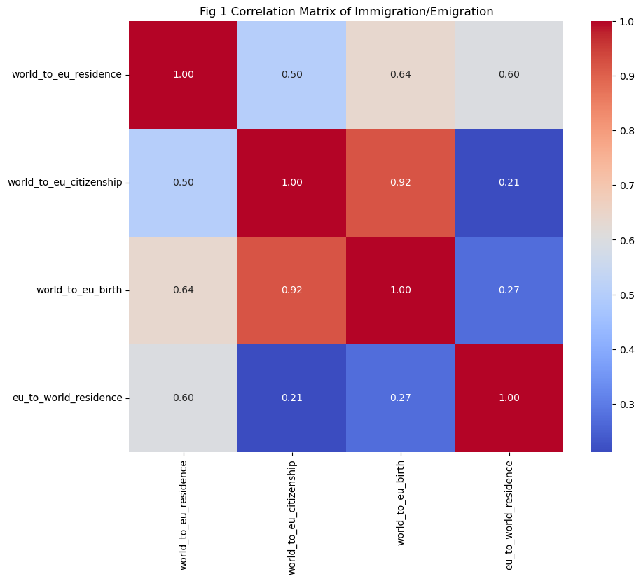

```python
# Compute correlation matrix
correlation_matrix = df_immigration[['world_to_eu_residence', 'world_to_eu_citizenship', 'world_to_eu_birth', 'eu_to_world_residence']].corr()

# Visualize correlation matrix using heatmap
plt.figure(figsize=(10, 8))
sns.heatmap(correlation_matrix, annot=True, cmap='coolwarm', fmt=".2f")
plt.title('Fig 1 Correlation Matrix of Immigration/Emigration')
plt.show()
```

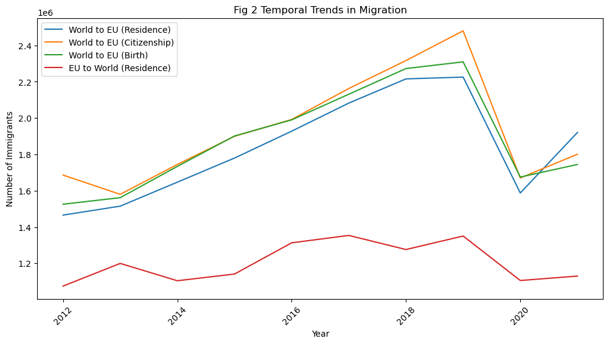

```python
# Temporal Trends in Migration
plt.figure(figsize=(12, 6))
sns.lineplot(data=df_immigration, x='Year', y='world_to_eu_residence', estimator='sum', ci=None)
sns.lineplot(data=df_immigration, x='Year', y='world_to_eu_citizenship', estimator='sum', ci=None)
sns.lineplot(data=df_immigration, x='Year', y='world_to_eu_birth', estimator='sum', ci=None)
sns.lineplot(data=df_immigration, x='Year', y='eu_to_world_residence', estimator='sum', ci=None)
plt.title('Fig 2 Temporal Trends in Migration')
plt.xlabel('Year')
plt.ylabel('Number of Immigrants')
plt.legend(['World to EU (Residence)', 'World to EU (Citizenship)', 'World to EU (Birth)', 'EU to World (Residence)'])
plt.xticks(rotation=45)
plt.show()
```

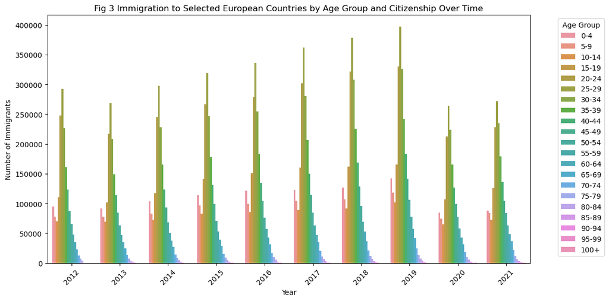

```python
# Bar plots of immigration/emigration over time
plt.figure(figsize=(12, 6))
sns.barplot(data=df_immigration, x='Year', y='world_to_eu_citizenship', hue='age', estimator=sum, ci=None)
plt.title('Fig 3 Immigration to Selected European Countries by Age Group and Citizenship Over Time')
plt.xlabel('Year')
plt.ylabel('Number of Immigrants')
plt.legend(title='Age Group', bbox_to_anchor=(1.05, 1), loc='upper left') # Adjust legend position
plt.xticks(rotation=45)
plt.tight_layout()
plt.show()
```

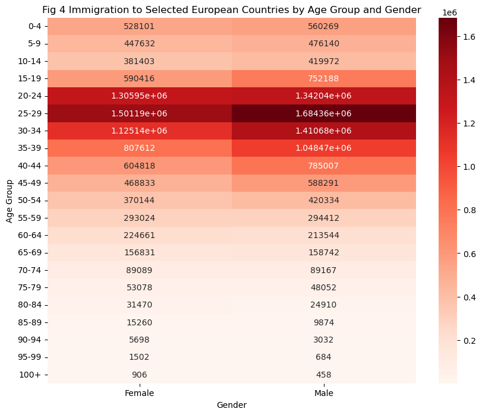

```python
# Heatmap of immigration by age and gender
plt.figure(figsize=(10, 8))
immigration_pivot = df_immigration.pivot_table(index='age', columns='sex', values='world_to_eu_citizenship', aggfunc=sum)
sns.heatmap(immigration_pivot, cmap='Reds', annot=True, fmt='g')
plt.title('Fig 4 Immigration to Selected European Countries by Age Group and Gender')
plt.xlabel('Gender')
plt.ylabel('Age Group')
plt.show()
```

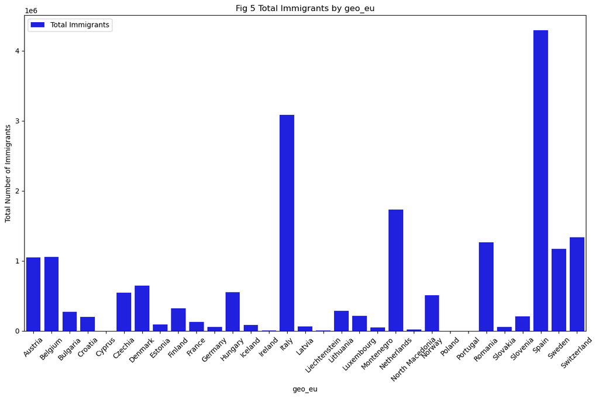

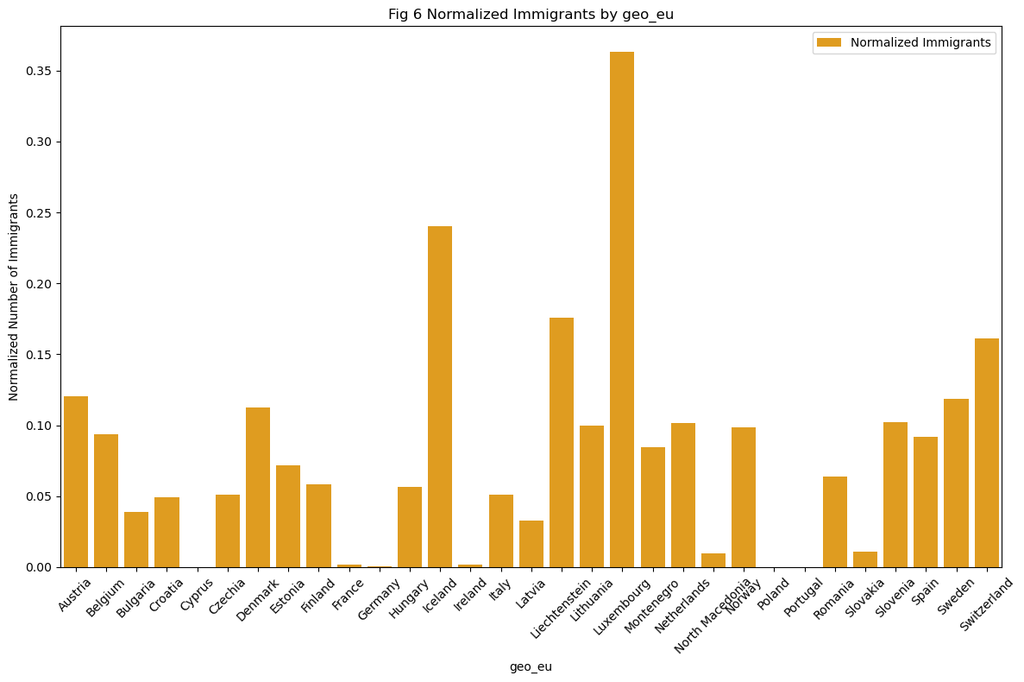

```python
# Set figure size
plt.figure(figsize=(12, 8))

# Plot total immigrants
sns.barplot(data=df_immigration, x='geo_eu', y='world_to_eu_citizenship', estimator=sum, ci=None, color='blue', label='Total Immigrants')

# Set labels and title for total immigrants plot
plt.title('Fig 5 Total Immigrants by geo_eu')
plt.xlabel('geo_eu')
plt.ylabel('Total Number of Immigrants')
plt.xticks(rotation=45)
plt.legend()

# Show the plot for total immigrants
plt.tight_layout()
plt.show()

# Set figure size for normalized immigrants
plt.figure(figsize=(12, 8))

# Plot normalized immigrants
sns.barplot(data=df_immigration, x='geo_eu', y='citizenship_ratio', estimator=sum, ci=None, color='orange', label='Normalized Immigrants')

# Set labels and title for normalized immigrants plot
plt.title('Fig 6 Normalized Immigrants by geo_eu')
plt.xlabel('geo_eu')
plt.ylabel('Normalized Number of Immigrants')
plt.xticks(rotation=45)
plt.legend()

# Show the plot for normalized immigrants
plt.tight_layout()
plt.show()
```

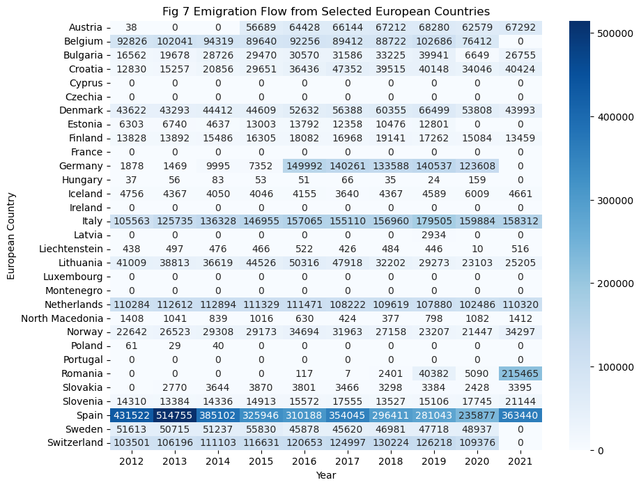

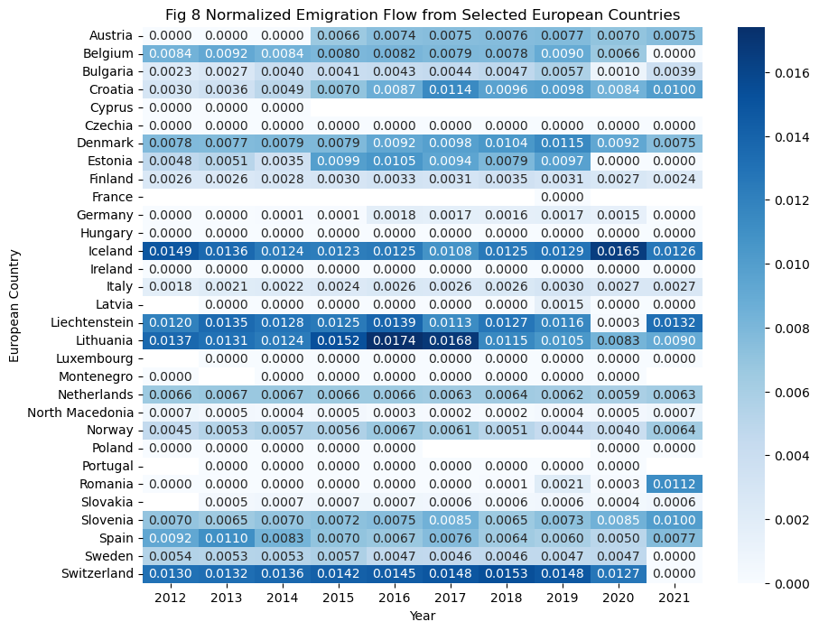

```python
# Emigration Flow Analysis
plt.figure(figsize=(10, 8))
emigration_flow_pivot = df_immigration.pivot_table(index='geo_eu', columns='Year', values='eu_to_world_residence', aggfunc=sum)
sns.heatmap(emigration_flow_pivot, cmap='Blues', annot=True, fmt='g')
plt.title('Fig 7 Emigration Flow from Selected European Countries')
plt.xlabel('Year')
plt.ylabel('European Country')
plt.show()

# Emigration Flow Analysis with normalization
plt.figure(figsize=(10, 8))
emigration_flow_pivot = df_immigration.pivot_table(index='geo_eu', columns='Year', values='eu_to_world_residence', aggfunc=sum)
population_pivot = df_immigration.pivot_table(index='geo_eu', columns='Year', values='geo_eu_population', aggfunc='first')
normalized_emigration_flow_pivot = emigration_flow_pivot.divide(population_pivot)

# Plot the heatmap
sns.heatmap(normalized_emigration_flow_pivot, cmap='Blues', annot=True, fmt='.4f')
plt.title('Fig 8 Normalized Emigration Flow from Selected European Countries')
plt.xlabel('Year')
plt.ylabel('European Country')
plt.show()
```

```python
# Filter data for countries in geo_eu and not in geo_eu
df_in_geo_eu = df_immigration[df_immigration['geo_world'].isin(df_immigration['geo_eu'])]
df_not_in_geo_eu = df_immigration[~df_immigration['geo_world'].isin(df_immigration['geo_eu'])]

# Group by geo_world and calculate the sum of world_to_eu_citizenship
grouped_in_geo_eu = df_in_geo_eu.groupby('geo_world')['world_to_eu_citizenship'].sum().reset_index()
grouped_not_in_geo_eu = df_not_in_geo_eu.groupby('geo_world')['world_to_eu_citizenship'].sum().reset_index()

# Filter countries where the sum of world_to_eu_citizenship is greater than 1
grouped_in_geo_eu_filtered = grouped_in_geo_eu[grouped_in_geo_eu['world_to_eu_citizenship'] > 1]
grouped_not_in_geo_eu_filtered = grouped_not_in_geo_eu[grouped_not_in_geo_eu['world_to_eu_citizenship'] > 1]

# Sort and select top 10 countries for countries in geo_eu
top_countries_in_geo_eu = grouped_in_geo_eu.nlargest(10, 'world_to_eu_citizenship')
top_countries_in_geo_eu_list = top_countries_in_geo_eu[['geo_world', 'world_to_eu_citizenship']].values.tolist()

# Sort and select top 10 countries for countries not in geo_eu
top_countries_not_in_geo_eu = grouped_not_in_geo_eu.nlargest(10, 'world_to_eu_citizenship')
top_countries_not_in_geo_eu_list = top_countries_not_in_geo_eu[['geo_world', 'world_to_eu_citizenship']].values.tolist()

# Display lists
print("Top 10 Countries in geo_eu:")
print(top_countries_in_geo_eu_list)
print("\nTop 10 Countries not in geo_eu:")
print(top_countries_not_in_geo_eu_list)
```

```
Top 10 Countries in geo_eu:
[['Romania', 2228813.0], ['Italy', 1005002.0], ['Spain', 802968.0], ['Germany', 635489.0], ['France', 584640.0], ['Netherlands', 576352.0], ['Poland', 525432.0], ['Hungary', 436796.0], ['Bulgaria', 398147.0], ['Sweden', 285147.0]]

Top 10 Countries not in geo_eu:
[['Morocco', 637095.0], ['Ukraine', 497430.0], ['Syria', 466457.0], ['China', 411464.0], ['United Kingdom', 408535.0], ['India', 364401.0], ['Colombia', 347660.0], ['Russia', 306199.0], ['Brazil', 265604.0], ['Venezuela', 258660.0]]
```

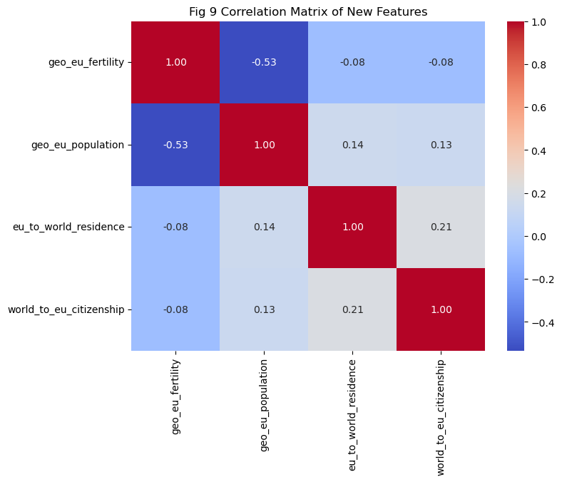

```python
# Correlation Analysis
correlation_matrix = df_immigration[['geo_eu_fertility', 'geo_eu_population', 'eu_to_world_residence', 'world_to_eu_citizenship']].corr()

plt.figure(figsize=(8, 6))
sns.heatmap(correlation_matrix, annot=True, cmap='coolwarm', fmt=".2f")
plt.title('Fig 9 Correlation Matrix of New Features')
plt.show()
```

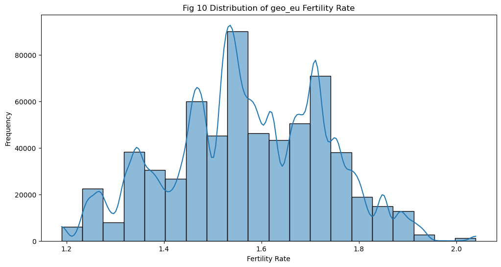

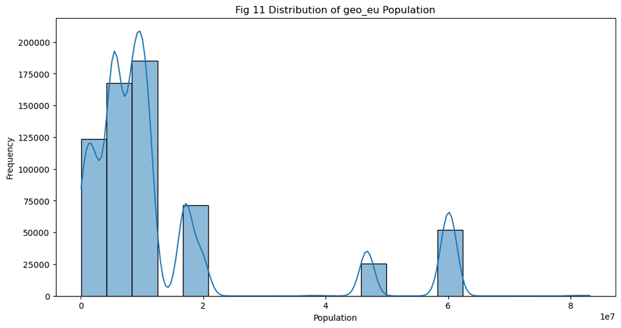

```python
# Exploration of New Features
plt.figure(figsize=(12, 6))
sns.histplot(data=df_immigration, x='geo_eu_fertility', bins=20, kde=True)
plt.title('Fig 10 Distribution of geo_eu Fertility Rate')
plt.xlabel('Fertility Rate')
plt.ylabel('Frequency')
plt.show()

plt.figure(figsize=(12, 6))
sns.histplot(data=df_immigration, x='geo_eu_population', bins=20, kde=True)
plt.title('Fig 11 Distribution of geo_eu Population')
plt.xlabel('Population')
plt.ylabel('Frequency')
plt.show()
```

**2.4 EDA Procedure: Feature Engineering**

In addition to the Feature Engineering techniques used in the previous section, additional unsupervised learning methods were explored to derive insights from the data. One such technique employed was K-Means clustering, which allowed us to identify underlying patterns and groupings within the dataset based on demographic and migration-related features.

Figures 12 and 13 introduce K-Means clustering. This particular clustering analysis focuses on the features added in feature engineering.

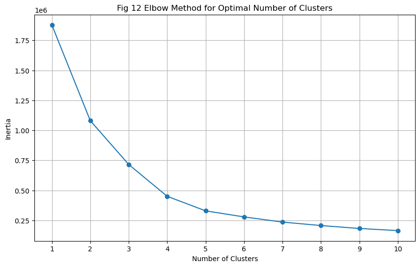

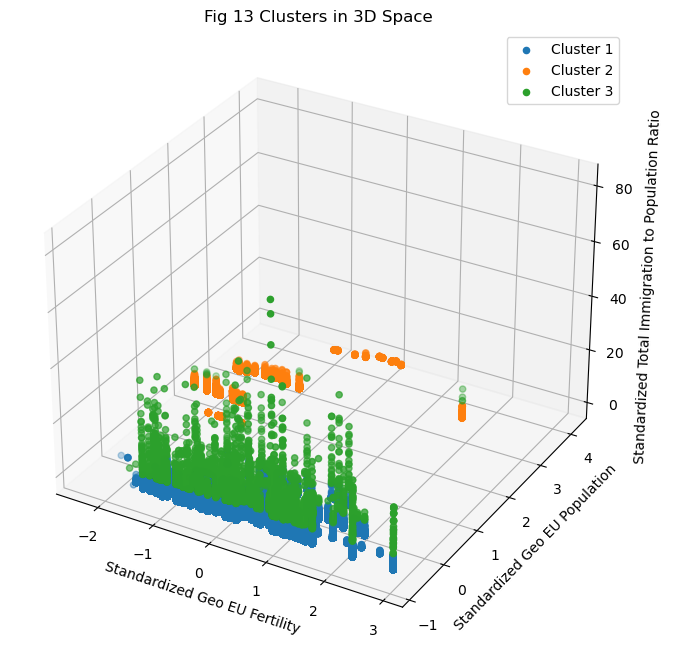

```python
# Select the features for clustering
X = df_immigration[['geo_eu_fertility', 'geo_eu_population', 'citizenship_ratio']]

# Standardize the features
scaler = StandardScaler()
X_scaled = scaler.fit_transform(X)

# Determine the optimal number of clusters using the elbow method
inertia = []
for k in range(1, 11):
    kmeans = KMeans(n_clusters=k, random_state=42)
    kmeans.fit(X_scaled)
    inertia.append(kmeans.inertia_)

# Plot the inertia (within-cluster sum of squared distances) against the number of clusters
plt.figure(figsize=(10, 6))
plt.plot(range(1, 11), inertia, marker='o')
plt.title('Fig 12 Elbow Method for Optimal Number of Clusters')
plt.xlabel('Number of Clusters')
plt.ylabel('Inertia')
plt.xticks(range(1, 11))
plt.grid(True)
plt.show()

# Based on the elbow method, select the optimal number of clusters
# Let's choose k=3 for demonstration purposes
k = 3

# Perform K-means clustering with the selected number of clusters
kmeans = KMeans(n_clusters=k, random_state=42)
clusters = kmeans.fit_predict(X_scaled)

# Add cluster labels to the dataframe
df_immigration['cluster'] = clusters

# Visualize the clusters in 3D space (for demonstration with 3 features)
from mpl_toolkits.mplot3d import Axes3D

fig = plt.figure(figsize=(10, 8))
ax = fig.add_subplot(111, projection='3d')

for cluster_label in range(k):
    cluster_data = X_scaled[clusters == cluster_label]
    ax.scatter(cluster_data[:, 0], cluster_data[:, 1], cluster_data[:, 2], label=f'Cluster {cluster_label + 1}')

ax.set_title('Fig 13 Clusters in 3D Space')
ax.set_xlabel('Standardized Geo EU Fertility')
ax.set_ylabel('Standardized Geo EU Population')
ax.set_zlabel('Standardized Total Immigration to Population Ratio')
ax.legend()
plt.show()
```

**2.5 EDA Procedure: Statistical Analysis**

The statistical analysis begins with a continued look at the K-Means clustering visible in Figures 12 and 13. From the elbow method, the optimal number of clusters is 3-4.

The two-sample t-test compares the mean immigration rates between male and female immigrants. With a very low p-value (significantly less than 0.05), we reject the null hypothesis of ther being no difference in the mean immigration rates between the two groups. This suggests that there is a significant difference in immigration rates between male and female immigrants.

The ANOVA results indicate that the age variable is an important factor in immigration rates. The high sum of squares suggest that there is considerable variability not explained by age but the p-value of 0.0 suggest that there is significant difference in immigration rates based on age.

The chi-square statistic value is approximately 2,778,170, and the corresponding p-value is extremely small (approximately 0). This indicates a significant association between the year and selected European countries (geo_eu) in terms of the number of immigrants, suggesting that the distribution of immigrants across those countries varies significantly over the years.

```python
# Create a DataFrame to store the elbow plot data
elbow_data = pd.DataFrame({'Number of Clusters': range(1, 11),
                           'Inertia': inertia})

# # Print the DataFrame
# print(elbow_data)

# Select the features for clustering
features = ['geo_eu_fertility', 'geo_eu_population', 'citizenship_ratio']
X = df_immigration[features]

# Standardize the features
scaler = StandardScaler()
X_scaled = scaler.fit_transform(X)

# Perform K-means clustering with the selected number of clusters (3 or 4)
k = 3
kmeans = KMeans(n_clusters=k, random_state=42)
clusters = kmeans.fit_predict(X_scaled)

# # Add cluster labels to the dataframe
# df_immigration['cluster'] = clusters

# Explore cluster characteristics
cluster_centers = scaler.inverse_transform(kmeans.cluster_centers_)  # Rescale cluster centers
cluster_labels = np.unique(clusters)

# Print cluster characteristics
for i, label in enumerate(cluster_labels):
    print(f"Cluster {label + 1} Characteristics:")
    print(f"  - Mean Fertility Rate: {cluster_centers[i, 0]:.2f}")
    print(f"  - Mean Population: {cluster_centers[i, 1]:.2f}")
    print(f"  - Mean Immigration to Population Ratio: {cluster_centers[i, 2]:.2f}")
    print()
```

```
Cluster 1 Characteristics:
  - Mean Fertility Rate: 1.61
  - Mean Population: 7939997.79
  - Mean Immigration to Population Ratio: 0.00

Cluster 2 Characteristics:
  - Mean Fertility Rate: 1.31
  - Mean Population: 55802444.12
  - Mean Immigration to Population Ratio: 0.00

Cluster 3 Characteristics:
  - Mean Fertility Rate: 1.59
  - Mean Population: 4290823.18
  - Mean Immigration to Population Ratio: 0.00
```

```python
# Male vs Female Immgration Hypothesis Testing
# Subset the data for the two groups (e.g., male and female)
group1_data = df_immigration[df_immigration['sex'] == 'Male']['world_to_eu_citizenship']
group2_data = df_immigration[df_immigration['sex'] == 'Female']['world_to_eu_citizenship']

# Perform a two-sample t-test to compare the means of the two groups
t_statistic, p_value = stats.ttest_ind(group1_data, group2_data)

# Print the results of the t-test
print("Two-sample t-test results:")
print("T-statistic:", t_statistic)
print("P-value:", p_value)

# Example of Linear Regression
# Model immigration to Europe based on selected features

# Select relevant features for the regression model
X = df_immigration[['world_to_eu_residence', 'world_to_eu_birth', 'eu_to_world_residence', 'geo_eu_population']]
y = df_immigration['world_to_eu_citizenship']

# Add constant term to the independent variables matrix for the intercept
X = sm.add_constant(X)

# Fit the linear regression model
model = sm.OLS(y, X).fit()

# Print the summary of the regression model
print("\nRegression Model Summary:")
print(model.summary())
```

```
Two-sample t-test results:
T-statistic: 6.143977736340886
P-value: 8.05283204923207e-10

Regression Model Summary:
                               OLS Regression Results
===================================================================================
Dep. Variable:     world_to_eu_citizenship   R-squared:                       0.858
Model:                                 OLS   Adj. R-squared:                  0.858
Method:                      Least Squares   F-statistic:                 9.435e+05
Date:                     Tue, 05 Mar 2024   Prob (F-statistic):               0.00
Time:                             18:41:03   Log-Likelihood:            -3.5594e+06
No. Observations:                   626242   AIC:                         7.119e+06
Df Residuals:                       626237   BIC:                         7.119e+06
Df Model:                                4
Covariance Type:                 nonrobust
=========================================================================================
                            coef    std err          t      P>|t|      [0.025      0.975]
-----------------------------------------------------------------------------------------
const                    -0.8812      0.117     -7.521      0.000      -1.111      -0.652
world_to_eu_residence    -0.2028      0.001   -217.739      0.000      -0.205      -0.201
world_to_eu_birth         1.1791      0.001   1611.997      0.000       1.178       1.181
eu_to_world_residence     0.0443      0.001     53.634      0.000       0.043       0.046
geo_eu_population      9.842e-08    5.5e-09     17.901      0.000    8.76e-08    1.09e-07
==============================================================================
Omnibus:                  1848571.769   Durbin-Watson:                   0.378
Prob(Omnibus):                  0.000   Jarque-Bera (JB):    1393085094418.025
Skew:                          40.903   Prob(JB):                         0.00
Kurtosis:                    7309.277   Cond. No.                     2.83e+07
==============================================================================

Notes:
[1] Standard Errors assume that the covariance matrix of the errors is correctly specified.
[2] The condition number is large, 2.83e+07. This might indicate that there are
strong multicollinearity or other numerical problems.
```

```python
# ANOVA
model = ols('world_to_eu_citizenship ~ age', data=df_immigration).fit()
anova_table = sm.stats.anova_lm(model, typ=2)

# Display ANOVA results
print("ANOVA Results:")
print(anova_table)
```

```
ANOVA Results:
                sum_sq        df           F  PR(>F)
age       1.804655e+08      20.0  255.694429     0.0
Residual  2.209889e+10  626221.0         NaN     NaN
```

```python
# Group by year and geo_eu, summing number of immigrants
grouped_data = df_immigration.groupby(['Year', 'geo_eu']).sum()['world_to_eu_citizenship'] + 1

# Convert grouped data to a contingency table
contingency_table = pd.pivot_table(grouped_data.reset_index(), values='world_to_eu_citizenship', index='Year', columns='geo_eu', fill_value=0)

# Chi-square test
chi2, p, dof, expected = chi2_contingency(contingency_table)

print("Chi-square statistic:", chi2)
print("P-value:", p)
```

```
Chi-square statistic: 2778170.153497561
P-value: 0.0
```

**2.6 Dimensionality Reduction**

The explained variance ratio indicates the proportion of variance explained by each principal component. In this case, the first principal component explains approximately 65.47% of the variance, while the second principal component explains approximately 25.07% of the variance. Together, these two principal components explain around 90.54% of the total variance in the data.

```python
# Select numerical columns for PCA
numeric_columns = ['world_to_eu_residence', 'world_to_eu_citizenship', 'world_to_eu_birth', 'eu_to_world_residence']

# Standardize the data
scaled_data = StandardScaler().fit_transform(df_immigration[numeric_columns])

# Perform PCA
pca = PCA(n_components=2)
principal_components = pca.fit_transform(scaled_data)

# Retrieve the coefficients of the principal components
principal_components_coef = pca.components_

# Print explained variance ratio
print("Explained variance ratio:", pca.explained_variance_ratio_)

# Print the coefficients of the principal components
print("Coefficients of the principal components:")
print(principal_components_coef)
```

```
Explained variance ratio: [0.65471851 0.25066655]
Coefficients of the principal components:
[[ 0.52006133  0.53006416  0.56626715  0.35764467]
 [ 0.3236365  -0.4497697  -0.35250687  0.75412568]]
```

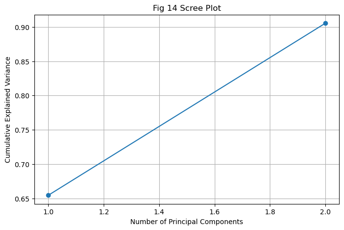

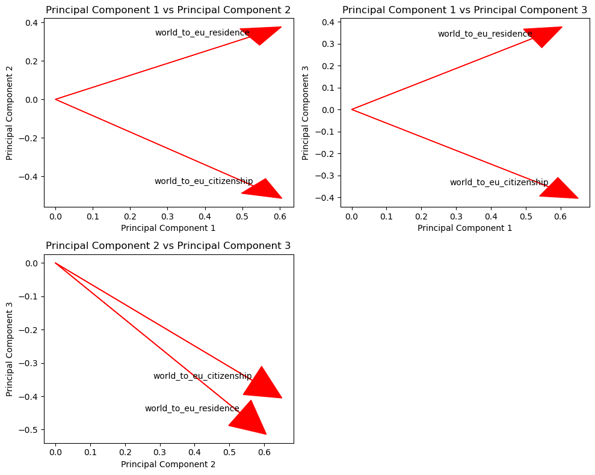

```
Feature Importance:
                              PC1       PC2
world_to_eu_residence    0.520061  0.323637
world_to_eu_citizenship  0.530064 -0.449770
world_to_eu_birth        0.566267 -0.352507
eu_to_world_residence    0.357645  0.754126
```

```python
# Scree Plot
plt.figure(figsize=(8, 5))
plt.plot(np.arange(1, len(pca.explained_variance_ratio_) + 1), np.cumsum(pca.explained_variance_ratio_), marker='o', linestyle='-')
plt.title('Fig 14 Scree Plot')
plt.xlabel('Number of Principal Components')
plt.ylabel('Cumulative Explained Variance')
plt.grid(True)
plt.show()

# Biplot
plt.figure(figsize=(10, 8))
for i, (comp1, comp2) in enumerate([(0, 1), (0, 2), (1, 2)]):  # Plot the pairs of components
    plt.subplot(2, 2, i + 1)
    for feature, (x, y) in zip(numeric_columns, principal_components_coef[:, [comp1, comp2]].T):
        plt.arrow(0, 0, x, y, head_width=0.1, head_length=0.1, fc='r', ec='r')
        plt.text(x, y, feature, ha='right', va='bottom')
    plt.xlabel(f'Principal Component {comp1 + 1}')
    plt.ylabel(f'Principal Component {comp2 + 1}')
    plt.title(f'Principal Component {comp1 + 1} vs Principal Component {comp2 + 1}')
plt.tight_layout()
plt.show()



# Feature Importance
feature_importance = pd.DataFrame(principal_components_coef.T, columns=[f'PC{i+1}' for i in range(pca.n_components_)], index=numeric_columns)
print("Feature Importance:")
print(feature_importance)
```

```python
# Identify original features with highest absolute coefficients for each principal component
top_features_pc1 = ['world_to_eu_residence', 'world_to_eu_citizenship', 'world_to_eu_birth', 'eu_to_world_residence']
top_features_pc2 = ['world_to_eu_residence', 'world_to_eu_citizenship', 'world_to_eu_birth', 'eu_to_world_residence']

# Perform dimensionality reduction by selecting top features from original dataset
selected_features = top_features_pc1 + top_features_pc2

# Create a new DataFrame with selected features
X_selected = df_immigration[selected_features]
```

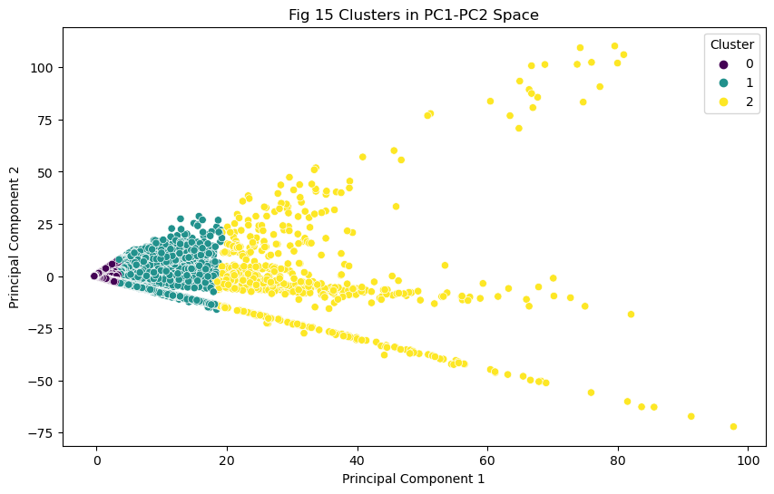

```python
# Standardize the data
X_cluster = df_immigration[selected_features]

scaler = StandardScaler()
X_cluster_scaled = scaler.fit_transform(X_cluster)

# Perform k-means clustering
kmeans = KMeans(n_clusters=3, random_state=42)
clusters = kmeans.fit_predict(X_cluster_scaled)

# Plot clusters based on two principal components
plt.figure(figsize=(10, 6))
sns.scatterplot(x=principal_components[:, 0], y=principal_components[:, 1], hue=clusters, palette='viridis')
plt.title('Fig 15 Clusters in PC1-PC2 Space')
plt.xlabel('Principal Component 1')
plt.ylabel('Principal Component 2')
plt.legend(title='Cluster')
plt.show()
```

**3 Analysis (Model Building and Training)**

This section predictive models are built and trained to forecast immigration patterns in the reporting European countries based on demographic and historical immigration data. The approach is one of supervised learning and utilizes Random Forest Regression and Linear Regression.

Model Types:

- The Random Forest Regression Model constructs multiple decision trees during training and outputs the mean prediction of the individual trees for regression tasks. It was chosen for the ability to handle complex relationships and interactions between dataset features.
- The Linear Regression Model assumes a linear relationship between the input feature variables and target variable. Although simple, it still provides valuable insight and can be used as a baseline performance metric for the more complex models.

Model Training and Evaluation:

The dataset is split into test and training datasets using a 20:80 ratio. For each model, a pipeline containing a preprocessing state and the regression algorithm. The preprocessing includes standardizing numerical features and encoding categorical variables.

Models are evaluated using the following metrics:

- Mean Squared Error (MSE): Measures the average squared difference between the predicted and actual values. Lower MSE indicates better model performance.
- Mean Absolute Error (MAE): Represents the average absolute difference between the predicted and actual values. Like MSE, lower MAE values indicate superior predictive accuracy.

Note: There are two sets of models built here. The first pair of models are the Random Forest and Linear Regression models that contain all the factors while the second pair of models do not contain any immigration information on birthplace or previous residence of immigrants.

```
Model: Random Forest
MSE Train: 44.53599929120768
MAE Train: 0.3197261638386165
MSE Test: 208.23144701354903
MAE Test: 0.8249011169749859
```

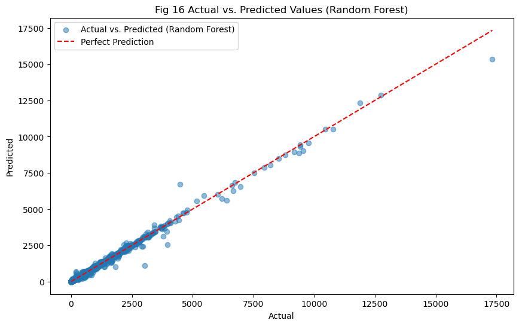

```
Model: Linear Regression
MSE Train: 4254.924233861539
MAE Train: 12.65905999114939
MSE Test: 3777.6669408898247
MAE Test: 12.638185664501385
```

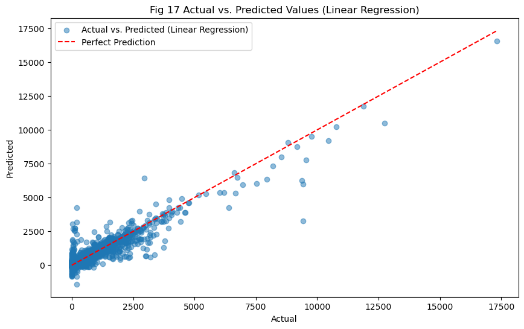

```python
# Define numeric and categorical columns
numeric_columns = ['world_to_eu_residence', 'world_to_eu_birth', 'eu_to_world_residence','citizenship_ratio', 'geo_eu_fertility', 'geo_eu_population']
categorical_columns = ['geo_eu', 'geo_world', 'age', 'sex']

# Define preprocessing steps
preprocessor = ColumnTransformer(
    transformers=[
        ('num', StandardScaler(), numeric_columns),  # Specify numeric columns and scaler
        ('cat', OneHotEncoder(), categorical_columns)  # Specify categorical columns and encoder
    ],
    remainder='passthrough'  # Keep any remaining columns as they are
)

# Define models
models = {
    'Random Forest': RandomForestRegressor(),
    'Linear Regression': LinearRegression()
}

# Split data into train and test sets
X_train, X_test, y_train, y_test = train_test_split(df_immigration.drop('world_to_eu_citizenship', axis=1), df_immigration['world_to_eu_citizenship'], test_size=0.2, random_state=42)

# Train and evaluate models
results = {}
for name, model in models.items():
    # Create pipeline with preprocessing and model
    pipe = Pipeline(steps=[('preprocessor', preprocessor), ('model', model)])
    pipe.fit(X_train, y_train)  # Train model
    y_pred_train = pipe.predict(X_train)  # Predict on training set
    y_pred_test = pipe.predict(X_test)  # Predict on test set

    # Evaluate model
    mse_train = mean_squared_error(y_train, y_pred_train)
    mae_train = mean_absolute_error(y_train, y_pred_train)
    mse_test = mean_squared_error(y_test, y_pred_test)
    mae_test = mean_absolute_error(y_test, y_pred_test)

    # Store results
    results[name] = {
        'MSE Train': mse_train,
        'MAE Train': mae_train,
        'MSE Test': mse_test,
        'MAE Test': mae_test,
        'y_pred_test': y_pred_test  # Store predicted values for later use
    }

# Display results and plot actual vs. predicted values
for i, (name, metrics) in enumerate(results.items(), start=16):
    print(f"Model: {name}")
    print(f"MSE Train: {metrics['MSE Train']}")
    print(f"MAE Train: {metrics['MAE Train']}")
    print(f"MSE Test: {metrics['MSE Test']}")
    print(f"MAE Test: {metrics['MAE Test']}")

    # Plotting actual vs. predicted values
    plt.figure(figsize=(10, 6))
    plt.scatter(y_test, metrics['y_pred_test'], label=f'Actual vs. Predicted ({name})', alpha=0.5)
    plt.plot([min(y_test), max(y_test)], [min(y_test), max(y_test)], color='red', linestyle='--', label='Perfect Prediction')
    plt.xlabel('Actual')
    plt.ylabel('Predicted')
    plt.title(f'Fig {i} Actual vs. Predicted Values ({name})')
    plt.legend()
    plt.show()
```

```
Model: Random Forest
MSE Train: 21.57979356737521
MAE Train: 0.09490709451030256
MSE Test: 61.912590807910625
MAE Test: 0.23894202748125734
```

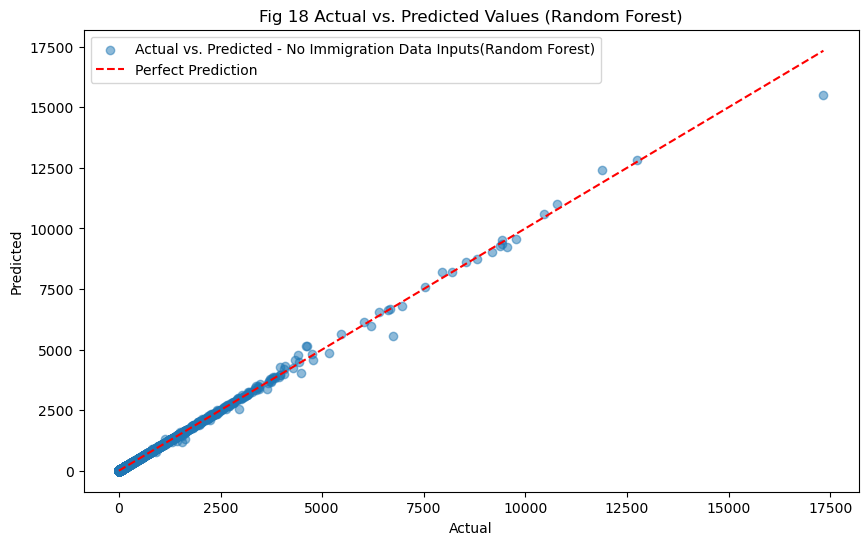

```
Model: Linear Regression
MSE Train: 22528.421370974942
MAE Train: 40.811142740699026
MSE Test: 25399.7919161394
MAE Test: 41.369754165886484
```

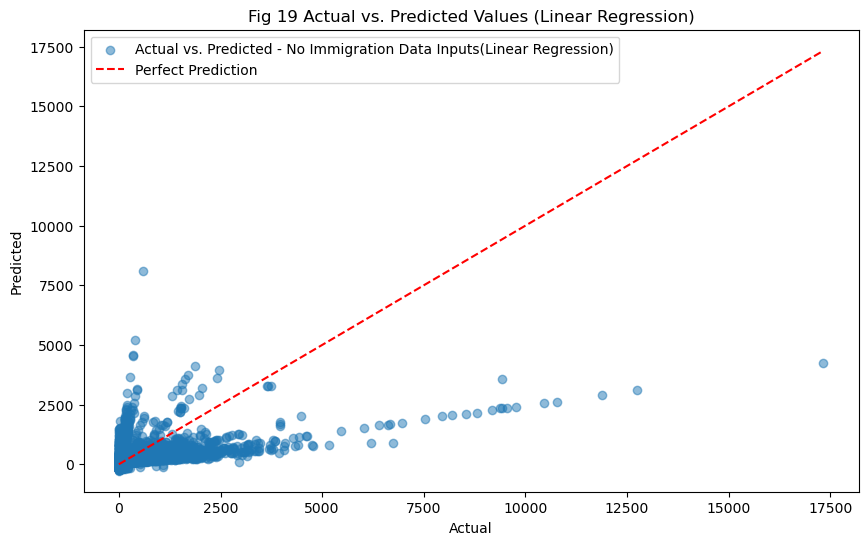

```python
# Define numeric and categorical columns
numeric_columns = ['eu_to_world_residence','citizenship_ratio', 'geo_eu_fertility', 'geo_eu_population']
categorical_columns = ['geo_eu', 'geo_world', 'age', 'sex']

# Define preprocessing steps
preprocessor = ColumnTransformer(
    transformers=[
        ('num', StandardScaler(), numeric_columns),  # Specify numeric columns and scaler
        ('cat', OneHotEncoder(), categorical_columns)  # Specify categorical columns and encoder
    ],
    remainder='passthrough'  # Keep any remaining columns as they are
)

# Define models
models = {
    'Random Forest': RandomForestRegressor(),
    'Linear Regression': LinearRegression()
}

# Drop columns 'world_to_eu_residence' and 'world_to_eu_birth' from predictor variables
X_train = X_train.drop(['world_to_eu_residence', 'world_to_eu_birth'], axis=1)
X_test = X_test.drop(['world_to_eu_residence', 'world_to_eu_birth'], axis=1)

# Train and evaluate models
results = {}
for name, model in models.items():
    # Create pipeline with preprocessing and model
    pipe = Pipeline(steps=[('preprocessor', preprocessor), ('model', model)])
    pipe.fit(X_train, y_train)  # Train model
    y_pred_train = pipe.predict(X_train)  # Predict on training set
    y_pred_test = pipe.predict(X_test)  # Predict on test set

    # Evaluate model
    mse_train = mean_squared_error(y_train, y_pred_train)
    mae_train = mean_absolute_error(y_train, y_pred_train)
    mse_test = mean_squared_error(y_test, y_pred_test)
    mae_test = mean_absolute_error(y_test, y_pred_test)

    # Store results
    results[name] = {
        'MSE Train': mse_train,
        'MAE Train': mae_train,
        'MSE Test': mse_test,
        'MAE Test': mae_test,
        'y_pred_test': y_pred_test  # Store predicted values for later use
    }

# Display results and plot actual vs. predicted values
for i, (name, metrics) in enumerate(results.items(), start=18):
    print(f"Model: {name}")
    print(f"MSE Train: {metrics['MSE Train']}")
    print(f"MAE Train: {metrics['MAE Train']}")
    print(f"MSE Test: {metrics['MSE Test']}")
    print(f"MAE Test: {metrics['MAE Test']}")

    # Plotting actual vs. predicted values
    plt.figure(figsize=(10, 6))
    plt.scatter(y_test, metrics['y_pred_test'], label=f'Actual vs. Predicted - No Immigration Data Inputs({name})', alpha=0.5)
    plt.plot([min(y_test), max(y_test)], [min(y_test), max(y_test)], color='red', linestyle='--', label='Perfect Prediction')
    plt.xlabel('Actual')
    plt.ylabel('Predicted')
    plt.title(f'Fig {i} Actual vs. Predicted Values ({name})')
    plt.legend()
    plt.show()
```

**4 Results**

The models were trained and evaluated using various features, and their predictive capabilities can be assessed based on mean squared error (MSE) and mean absolute error (MAE) metrics.

The first pair of models exhibited the following performance metrics:

After excluding certain features, these are the metrics of the second pair of models:

Overall, the Random Forest model performed well and outperformed the Linear Regression model in terms of both MSE and MAE across all scenarios. Excluding certain features led to improved performance of the Random Forest model, while the Linear Regression model saw a massive decrease in performance.

The discrepancy in performance could be due to non-linear or complex relationships between features.

**5 Conclusion**

This analysis explored the performance of Random Forest and Linear Regression models in predicting world-to-select EU-countries immigration patterns. The investigation involved evaluating the models both with and without the inclusion of certain predictor variables, aiming to understand the impact of feature removal on model performance.

- Summary of Findings

The results indicate that both Random Forest and Linear Regression models exhibited variations in performance when certain features were excluded from the analysis. The Random Forest model improved in performance while the Linear Regression model declined.

- Impact of Feature Removal and Model Comparison

Upon removing select immigrant data, we observed notable changes in model performance, despite the high correlation between the target variable and said data. The Random Forest model demonstrated an improvement in both Mean Squared Error (MSE) and Mean Absolute Error (MAE) metrics. However, the Linear Regression model experienced a degradation in performance, with higher MSE and MAE values compared to the full feature set scenario. The Random Forest models were both competitive as target variable predictors while only the complete Linear Regression model appeared to be a remotely reasonable predictor.

- Interpretation of Results

The contrasting behavior of the Random Forest and Linear Regression models highlights the differences in their ability to handle feature complexity and interactions. Random Forest's ensemble approach may have benefited from feature reduction by focusing on the most informative variables, while Linear Regression's linear relationship assumption may have been compromised by the absence of certain features.

- Implications and Recommendations

The observed differences in model performance have significant implications for EU immigration prediction. Random Forest's ability to adapt to feature reduction suggests potential utility in scenarios where feature interpretability is less critical, prioritizing predictive accuracy instead. Conversely, Linear Regression's sensitivity to feature completeness highlights the importance of comprehensive data collection and feature engineering in EU immigration forecasting.

- Limitations and Future Research

It is important to note that the dataset analyzed had aspects that were visibly incomplete. Future research could aim to acquire or estimate some of those aspects. Furthermore future research could look to evaluate impact of GDP, quality of life, or policy changes to advance understanding of EU immigration dynamics and enhance the efficacy of predictive modeling techniques.